# **21i-2081**

# Loading the WorldBankData.csv

```r
#reading the worldbankdata
WorldBankData <- read.csv("/content/WorldBankData.csv", header=TRUE)
View(WorldBankData)
```

A data.frame: 13303 × 14

| Country <chr> | Country.Code <chr> | year <int> | Region <chr> | IncomeGroup <chr> | population <dbl> | rural.population <dbl> | hiv.cases <int> | san.access <dbl> | motor.vehicles <int> | gas.price <dbl> | co2.emission <dbl> | mobile.users <dbl> | internet.users <dbl> |
| --- | --- | --- | --- | --- | --- | --- | --- | --- | --- | --- | --- | --- | --- |
| Aruba | ABW | 1960 | Latin America & Caribbean | High income | 54208 | 26683 | NA | NA | NA | NA | NA | 0 | NA |
| Aruba | ABW | 1961 | Latin America & Caribbean | High income | 55435 | 27296 | NA | NA | NA | NA | NA | NA | NA |
| Aruba | ABW | 1962 | Latin America & Caribbean | High income | 56226 | 27694 | NA | NA | NA | NA | NA | NA | NA |
| Aruba | ABW | 1963 | Latin America & Caribbean | High income | 56697 | 27934 | NA | NA | NA | NA | NA | NA | NA |
| Aruba | ABW | 1964 | Latin America & Caribbean | High income | 57029 | 28107 | NA | NA | NA | NA | NA | NA | NA |
| Aruba | ABW | 1965 | Latin America & Caribbean | High income | 57360 | 28278 | NA | NA | NA | NA | NA | 0 | NA |
| Aruba | ABW | 1966 | Latin America & Caribbean | High income | 57712 | 28461 | NA | NA | NA | NA | NA | NA | NA |
| Aruba | ABW | 1967 | Latin America & Caribbean | High income | 58049 | 28636 | NA | NA | NA | NA | NA | NA | NA |
| Aruba | ABW | 1968 | Latin America & Caribbean | High income | 58385 | 28810 | NA | NA | NA | NA | NA | NA | NA |
| Aruba | ABW | 1969 | Latin America & Caribbean | High income | 58724 | 28987 | NA | NA | NA | NA | NA | NA | NA |
| Aruba | ABW | 1970 | Latin America & Caribbean | High income | 59065 | 29164 | NA | NA | NA | NA | NA | 0 | NA |
| Aruba | ABW | 1971 | Latin America & Caribbean | High income | 59438 | 29357 | NA | NA | NA | NA | NA | NA | NA |
| Aruba | ABW | 1972 | Latin America & Caribbean | High income | 59849 | 29569 | NA | NA | NA | NA | NA | NA | NA |
| Aruba | ABW | 1973 | Latin America & Caribbean | High income | 60239 | 29771 | NA | NA | NA | NA | NA | NA | NA |
| Aruba | ABW | 1974 | Latin America & Caribbean | High income | 60525 | 29922 | NA | NA | NA | NA | NA | NA | NA |
| Aruba | ABW | 1975 | Latin America & Caribbean | High income | 60655 | 29995 | NA | NA | NA | NA | NA | 0 | NA |
| Aruba | ABW | 1976 | Latin America & Caribbean | High income | 60589 | 29972 | NA | NA | NA | NA | NA | 0 | NA |
| Aruba | ABW | 1977 | Latin America & Caribbean | High income | 60366 | 29871 | NA | NA | NA | NA | NA | 0 | NA |
| Aruba | ABW | 1978 | Latin America & Caribbean | High income | 60106 | 29751 | NA | NA | NA | NA | NA | 0 | NA |
| Aruba | ABW | 1979 | Latin America & Caribbean | High income | 59978 | 29697 | NA | NA | NA | NA | NA | 0 | NA |
| Aruba | ABW | 1980 | Latin America & Caribbean | High income | 60096 | 29764 | NA | NA | NA | NA | NA | 0 | NA |
| Aruba | ABW | 1981 | Latin America & Caribbean | High income | 60567 | 30007 | NA | NA | NA | NA | NA | 0 | NA |
| Aruba | ABW | 1982 | Latin America & Caribbean | High income | 61344 | 30401 | NA | NA | NA | NA | NA | 0 | NA |
| Aruba | ABW | 1983 | Latin America & Caribbean | High income | 62204 | 30837 | NA | NA | NA | NA | NA | 0 | NA |
| Aruba | ABW | 1984 | Latin America & Caribbean | High income | 62831 | 31158 | NA | NA | NA | NA | NA | 0 | NA |
| Aruba | ABW | 1985 | Latin America & Caribbean | High income | 63028 | 31265 | NA | NA | NA | NA | NA | 0 | NA |
| Aruba | ABW | 1986 | Latin America & Caribbean | High income | 62644 | 31084 | NA | NA | NA | NA | 179.683 | 0 | NA |
| Aruba | ABW | 1987 | Latin America & Caribbean | High income | 61835 | 30692 | NA | NA | NA | NA | 447.374 | 0 | NA |
| Aruba | ABW | 1988 | Latin America & Caribbean | High income | 61077 | 30325 | NA | NA | NA | NA | 612.389 | 0 | NA |
| Aruba | ABW | 1989 | Latin America & Caribbean | High income | 61032 | 30312 | NA | NA | NA | NA | 649.059 | 0 | NA |
| ⋮ | ⋮ | ⋮ | ⋮ | ⋮ | ⋮ | ⋮ | ⋮ | ⋮ | ⋮ | ⋮ | ⋮ | ⋮ | ⋮ |
| Zimbabwe | ZWE | 1983 | Sub-Saharan Africa | Low income | 8197858 | 6214239 | NA | NA | NA | NA | 10461.951 | 0 | NA |
| Zimbabwe | ZWE | 1984 | Sub-Saharan Africa | Low income | 8527836 | 6412472 | NA | NA | NA | NA | 9922.902 | 0 | NA |
| Zimbabwe | ZWE | 1985 | Sub-Saharan Africa | Low income | 8860331 | 6608566 | NA | NA | NA | NA | 10263.933 | 0 | NA |
| Zimbabwe | ZWE | 1986 | Sub-Saharan Africa | Low income | 9193889 | 6791636 | NA | NA | NA | NA | 13127.860 | 0 | NA |
| Zimbabwe | ZWE | 1987 | Sub-Saharan Africa | Low income | 9527192 | 6969751 | NA | NA | NA | NA | 15240.052 | 0 | NA |
| Zimbabwe | ZWE | 1988 | Sub-Saharan Africa | Low income | 9854098 | 7138466 | NA | NA | NA | NA | 16101.797 | 0 | NA |
| Zimbabwe | ZWE | 1989 | Sub-Saharan Africa | Low income | 10167392 | 7292745 | NA | NA | NA | NA | 16186.138 | 0 | NA |
| Zimbabwe | ZWE | 1990 | Sub-Saharan Africa | Low income | 10461782 | 7429121 | 1119411 | 4249257 | NA | NA | 15504.076 | 0 | 0 |
| Zimbabwe | ZWE | 1991 | Sub-Saharan Africa | Low income | 10733048 | 7562849 | 1524093 | NA | NA | 0.68 | 15823.105 | 0 | NA |
| Zimbabwe | ZWE | 1992 | Sub-Saharan Africa | Low income | 10981267 | 7677487 | 1943684 | NA | NA | 0.47 | 16901.203 | 0 | NA |
| Zimbabwe | ZWE | 1993 | Sub-Saharan Africa | Low income | 11210802 | 7776440 | 2354268 | NA | NA | NA | 16208.140 | 0 | NA |
| Zimbabwe | ZWE | 1994 | Sub-Saharan Africa | Low income | 11428655 | 7864835 | 2708591 | NA | NA | NA | 17645.604 | 0 | 199 |
| Zimbabwe | ZWE | 1995 | Sub-Saharan Africa | Low income | 11639364 | 7945961 | 3002956 | 4716414 | NA | 0.38 | 15130.042 | 0 | 894 |
| Zimbabwe | ZWE | 1996 | Sub-Saharan Africa | Low income | 11846110 | 8039102 | 3210296 | NA | NA | NA | 14994.363 | 0 | 1989 |
| Zimbabwe | ZWE | 1997 | Sub-Saharan Africa | Low income | 12045813 | 8125816 | 3324644 | NA | NA | NA | 14407.643 | 5734 | 3985 |
| Zimbabwe | ZWE | 1998 | Sub-Saharan Africa | Low income | 12229500 | 8200173 | 3363113 | NA | NA | 0.26 | 14253.629 | 19000 | 9985 |
| Zimbabwe | ZWE | 1999 | Sub-Saharan Africa | Low income | 12384727 | 8254074 | 3319107 | NA | NA | NA | 15834.106 | 174000 | 20023 |
| Zimbabwe | ZWE | 2000 | Sub-Saharan Africa | Low income | 12503652 | 8282669 | 3213439 | 5039058 | NA | 0.85 | 13886.929 | 266441 | 50194 |
| Zimbabwe | ZWE | 2001 | Sub-Saharan Africa | Low income | 12586763 | 8284809 | 3058583 | NA | NA | NA | 12563.142 | 314002 | 100675 |
| Zimbabwe | ZWE | 2002 | Sub-Saharan Africa | Low income | 12640922 | 8267315 | 2882130 | NA | NA | 0.05 | 11932.418 | 338779 | 504923 |
| Zimbabwe | ZWE | 2003 | Sub-Saharan Africa | Low income | 12673103 | 8235084 | 2699371 | NA | NA | NA | 10626.966 | 363651 | 810418 |
| Zimbabwe | ZWE | 2004 | Sub-Saharan Africa | Low income | 12693047 | 8194682 | 2513223 | NA | NA | 0.61 | 9926.569 | 425745 | 833177 |
| Zimbabwe | ZWE | 2005 | Sub-Saharan Africa | Low income | 12710589 | 8152572 | 2338748 | 5097195 | NA | NA | 10773.646 | 647110 | 1018878 |
| Zimbabwe | ZWE | 2006 | Sub-Saharan Africa | Low income | 12724308 | 8103603 | 2201305 | NA | NA | NA | 10344.607 | 849146 | 1245944 |
| Zimbabwe | ZWE | 2007 | Sub-Saharan Africa | Low income | 12740160 | 8055858 | 2089386 | NA | 1445877 | NA | 10212.595 | 1225654 | 1382307 |
| Zimbabwe | ZWE | 2008 | Sub-Saharan Africa | Low income | 12784041 | 8025565 | 2007094 | NA | NA | 1.30 | 8148.074 | 1654721 | 1457381 |
| Zimbabwe | ZWE | 2009 | Sub-Saharan Africa | Low income | 12888918 | 8032889 | 1959116 | NA | NA | NA | 8734.794 | 3991000 | 1464181 |
| Zimbabwe | ZWE | 2010 | Sub-Saharan Africa | Low income | 13076978 | 8090726 | 1961547 | 5223347 | NA | 1.29 | 9427.857 | 7700000 | 1503852 |
| Zimbabwe | ZWE | 2011 | Sub-Saharan Africa | Low income | 13358738 | 8199513 | 1990452 | NA | NA | NA | NA | 9200000 | 2097322 |
| Zimbabwe | ZWE | 2012 | Sub-Saharan Africa | Low income | 13724317 | 8356572 | 2017475 | 5474855 | NA | 1.52 | NA | 12613935 | 2345596 |

# Preprocessing and filtering the Data(Removing NA values and getting Denmark, Belarus data)

```r
#Filtering the Data
Data<-WorldBankData[WorldBankData$year>=1990,]
Denmark_Data<-Data[Data$Country=="Denmark",]
Belarus_Data<-Data[Data$Country=="Belarus",]
#Removing the NA values
Belarus_Data<-Belarus_Data[!is.na(Belarus_Data$internet.users),]
```

```r
Belarus_Data
```

A data.frame: 17 × 14

|  | Country <chr> | Country.Code <chr> | year <int> | Region <chr> | IncomeGroup <chr> | population <dbl> | rural.population <dbl> | hiv.cases <int> | san.access <dbl> | motor.vehicles <int> | gas.price <dbl> | co2.emission <dbl> | mobile.users <dbl> | internet.users <dbl> |
| --- | --- | --- | --- | --- | --- | --- | --- | --- | --- | --- | --- | --- | --- | --- |
| 1250 | Belarus | BLR | 1990 | Europe & Central Asia | Upper middle income | 10189000 | 3466196 | 10189 | 9699876 | NA | NA | NA | 0 | 1 |
| 1254 | Belarus | BLR | 1994 | Europe & Central Asia | Upper middle income | 10227000 | 3319991 | 10227 | NA | NA | NA | 65914.32 | 1725 | 50 |
| 1255 | Belarus | BLR | 1995 | Europe & Central Asia | Upper middle income | 10194000 | 3269624 | 10194 | 9697050 | NA | NA | 62118.98 | 5900 | 298 |
| 1256 | Belarus | BLR | 1996 | Europe & Central Asia | Upper middle income | 10160000 | 3217123 | 10160 | NA | NA | NA | 60157.14 | 6550 | 2977 |
| 1257 | Belarus | BLR | 1997 | Europe & Central Asia | Upper middle income | 10117000 | 3162089 | 10117 | NA | NA | NA | 59519.08 | 8164 | 4959 |
| 1258 | Belarus | BLR | 1998 | Europe & Central Asia | Upper middle income | 10069000 | 3105864 | 10069 | NA | NA | 0.34 | 57597.57 | 12141 | 7438 |
| 1259 | Belarus | BLR | 1999 | Europe & Central Asia | Upper middle income | 10035000 | 3054293 | 10035 | NA | NA | NA | 55819.07 | 23458 | 49661 |
| 1260 | Belarus | BLR | 2000 | Europe & Central Asia | Upper middle income | 10005000 | 3004201 | 10005 | 9496543 | 1886994 | 0.55 | 53468.53 | 49469 | 186133 |
| 1261 | Belarus | BLR | 2001 | Europe & Central Asia | Upper middle income | 9928000 | 2933803 | 9928 | NA | 1867522 | NA | 52595.78 | 138438 | 426965 |
| 1262 | Belarus | BLR | 2002 | Europe & Central Asia | Upper middle income | 9865000 | 2868209 | 19730 | NA | 1934603 | 0.50 | 52390.43 | 463200 | 883013 |
| 1266 | Belarus | BLR | 2006 | Europe & Central Asia | Upper middle income | 9604000 | 2611693 | 28812 | NA | 2405840 | 0.79 | 61829.29 | 5949865 | 1555848 |
| 1267 | Belarus | BLR | 2007 | Europe & Central Asia | Upper middle income | 9560000 | 2556497 | 28680 | NA | 2562384 | NA | 60281.81 | 6941580 | 1883320 |
| 1268 | Belarus | BLR | 2008 | Europe & Central Asia | Upper middle income | 9528000 | 2504854 | 38112 | NA | 2705365 | 1.33 | 62815.71 | 8104353 | 2191440 |
| 1269 | Belarus | BLR | 2009 | Europe & Central Asia | Upper middle income | 9507000 | 2456343 | 38028 | NA | 2870674 | NA | 60292.81 | 9667099 | 2607770 |
| 1270 | Belarus | BLR | 2010 | Europe & Central Asia | Upper middle income | 9490000 | 2409036 | 37960 | 8959599 | 3042665 | 1.08 | 62221.66 | 10331735 | 3017820 |
| 1271 | Belarus | BLR | 2011 | Europe & Central Asia | Upper middle income | 9473000 | 2366204 | 37892 | NA | 3190094 | NA | NA | 10720486 | 3751308 |
| 1272 | Belarus | BLR | 2012 | Europe & Central Asia | Upper middle income | 9464000 | 2325475 | 37856 | 8927301 | NA | 0.88 | NA | 10743336 | 4439184 |

# Plotting the year and internet.users relations and try to visualize the trend of Belarus Data

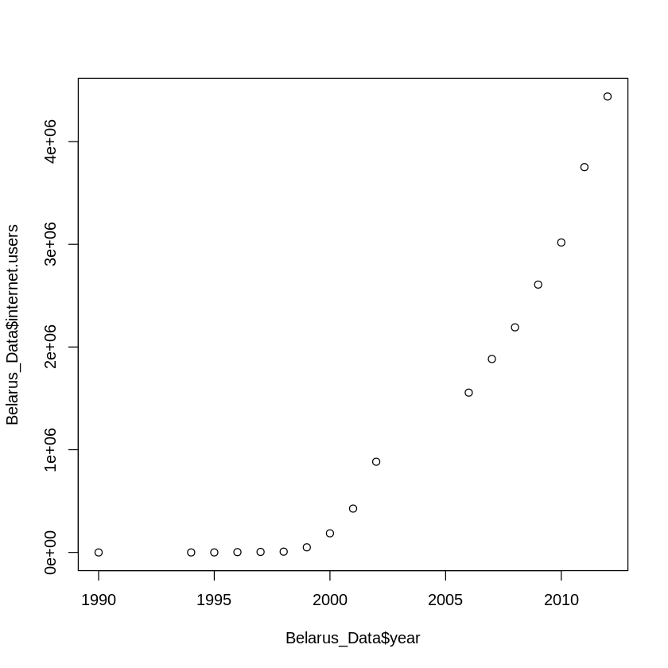

```r
plot(Belarus_Data$year,Belarus_Data$internet.users)
```

# Plotting the year and internet.users relations and try to visualize the trend of Denmark Data

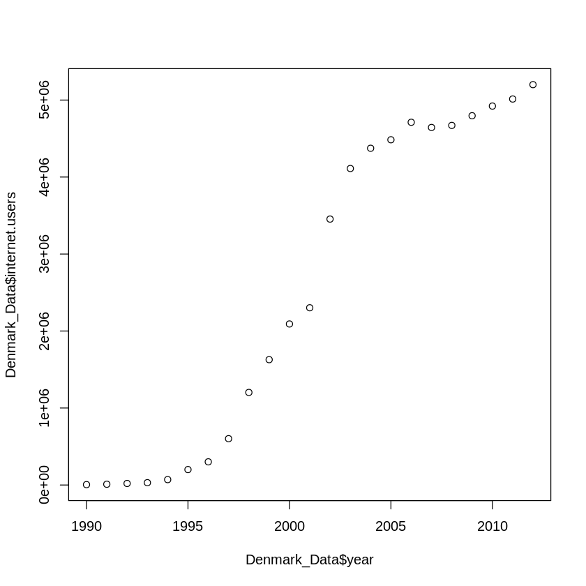

```r
plot(Denmark_Data$year,Denmark_Data$internet.users)
```

# **Just by looking at the plotted graph between year and internet.users behavior we can clearly claim Belarus can fit the Exponetinal Model well and Denmark seems to show logistic behaviour so it will fit the Logistic model well**

# However, we can also statistically prove that which model is best by calculating R square for each and the maximum of RSqaure value can prove this is the best model.

# Fitting Linear Model for Belarus Data

```r
#lm function which autmatically fit the data by taking dependent and independent values
LinearModel.fit = lm(internet.users~year, data=Belarus_Data)
#Summary function returns all the basis details
summary(LinearModel.fit)
```

```
Call:
lm(formula = internet.users ~ year, data = Belarus_Data)

Residuals:
    Min      1Q  Median      3Q     Max
-628450 -397987 -195887  208610 1231208

Coefficients:
              Estimate Std. Error t value Pr(>|t|)
(Intercept) -408343501   44819655  -9.111 1.68e-07 ***
year            204579      22387   9.138 1.61e-07 ***
---
Signif. codes:  0 ‘***’ 0.001 ‘**’ 0.01 ‘*’ 0.05 ‘.’ 0.1 ‘ ’ 1

Residual standard error: 600300 on 15 degrees of freedom
Multiple R-squared:  0.8477,	Adjusted R-squared:  0.8376
F-statistic: 83.51 on 1 and 15 DF,  p-value: 1.613e-07
```

# Plotting Residuals Fits

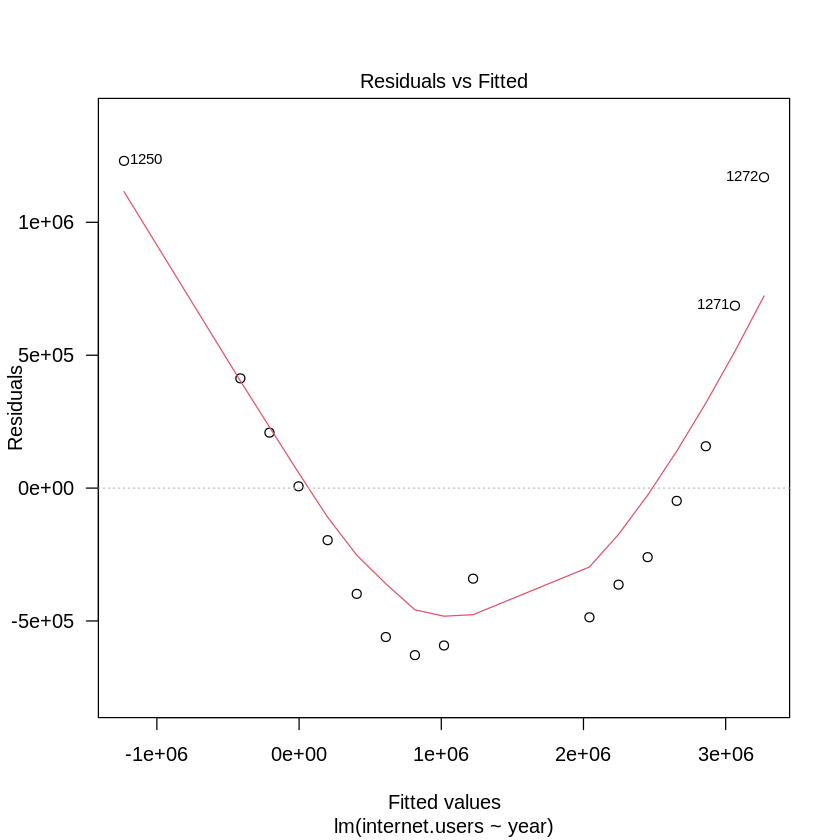

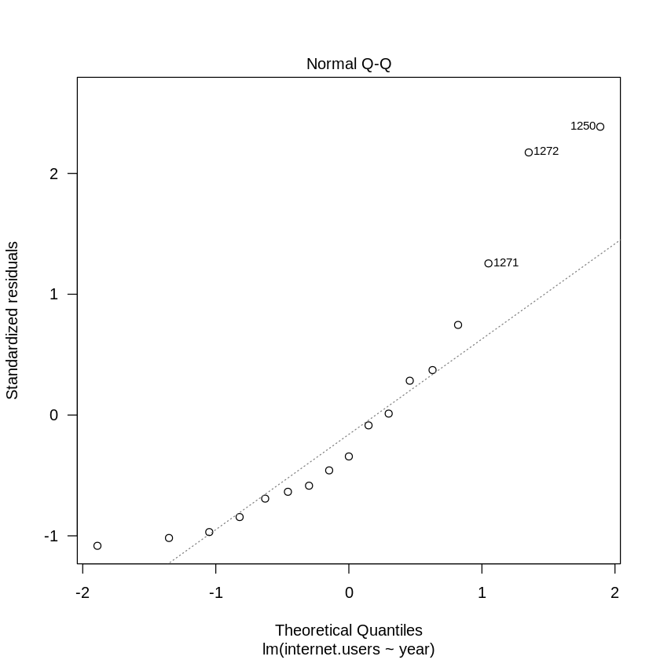

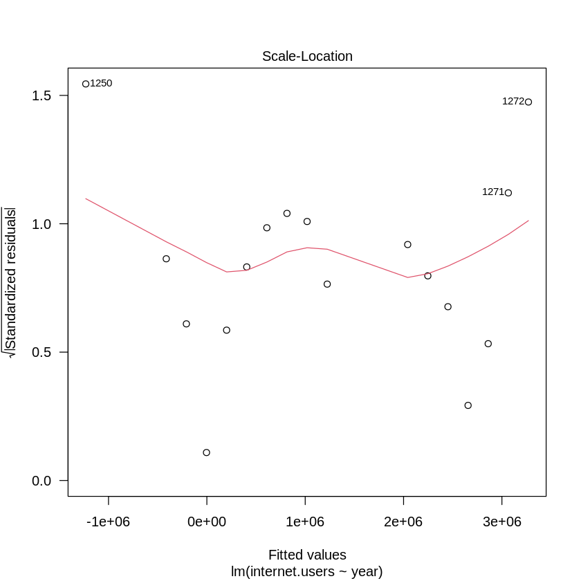

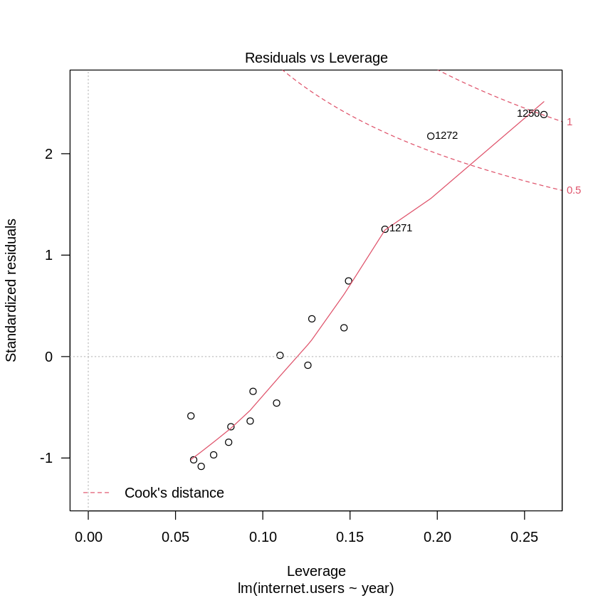

```r
plot(LinearModel.fit, las = 1)      # Residuals, Fitted, ...
```

# Fitting ExponentialModel for Berlarus Data

```r
require(graphics)
ExponentialModel.fit = lm(log(internet.users)~year, data=Belarus_Data)
summary(ExponentialModel.fit)
```

```
Call:
lm(formula = log(internet.users) ~ year, data = Belarus_Data)

Residuals:
    Min      1Q  Median      3Q     Max
-3.5014 -1.1232  0.2866  0.7347  2.6646

Coefficients:
              Estimate Std. Error t value Pr(>|t|)
(Intercept) -1.244e+03  1.354e+02  -9.194 1.49e-07 ***
year         6.271e-01  6.761e-02   9.276 1.33e-07 ***
---
Signif. codes:  0 ‘***’ 0.001 ‘**’ 0.01 ‘*’ 0.05 ‘.’ 0.1 ‘ ’ 1

Residual standard error: 1.813 on 15 degrees of freedom
Multiple R-squared:  0.8515,	Adjusted R-squared:  0.8416
F-statistic: 86.04 on 1 and 15 DF,  p-value: 1.331e-07
```

# Plotting Residuals Fits

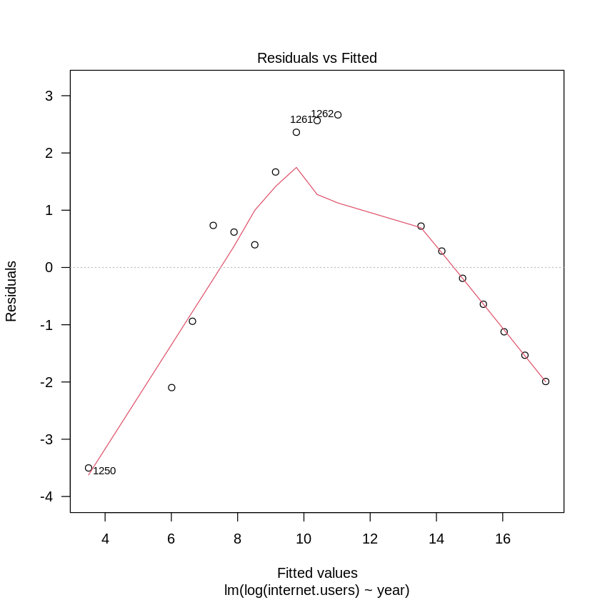

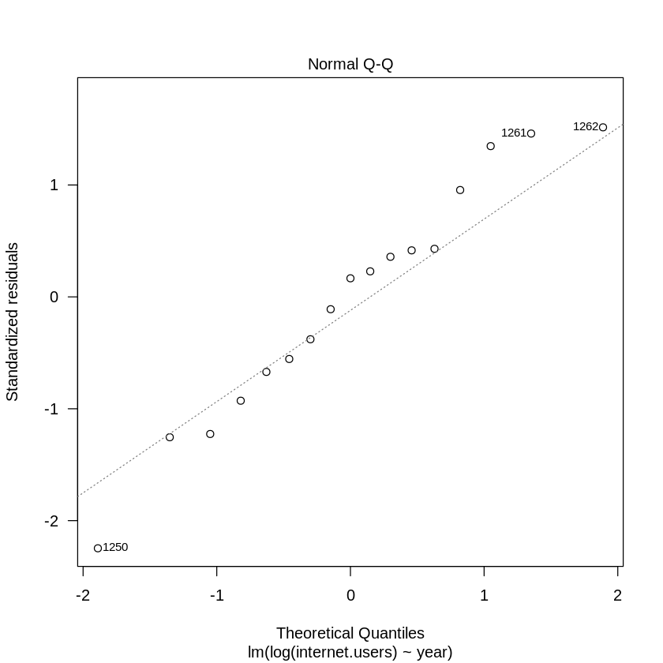

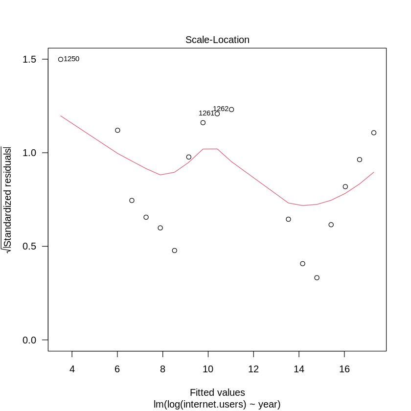

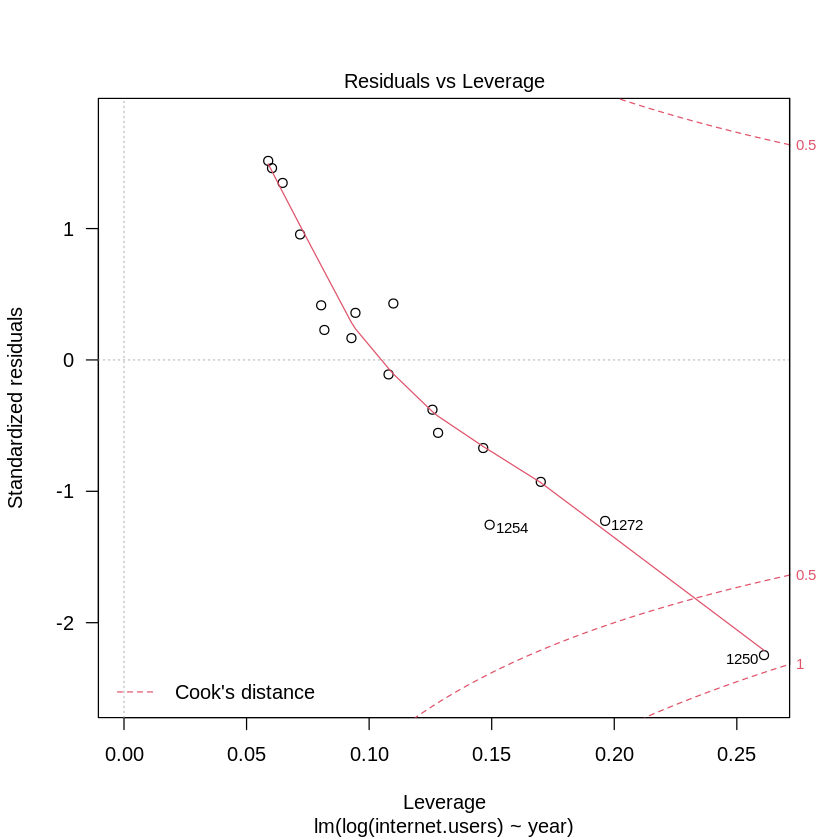

```r
plot(ExponentialModel.fit, las = 1)      # Residuals, Fitted, ...
```

# Fitting Logistic Model for Berlarus Data

```r
Belarus_Data$internet.users=factor(Belarus_Data$internet.users)
logistic_model <- glm(internet.users~year ,
                      data = Belarus_Data,
                      family = "binomial")
summary(logistic_model)
```

```
Call:
glm(formula = internet.users ~ year, family = "binomial", data = Belarus_Data)

Deviance Residuals:
       Min          1Q      Median          3Q         Max
-2.248e-05   2.110e-08   2.110e-08   2.110e-08   3.069e-05

Coefficients:
              Estimate Std. Error z value Pr(>|z|)
(Intercept) -2.170e+04  2.357e+07  -0.001    0.999
year         1.089e+01  1.183e+04   0.001    0.999

(Dispersion parameter for binomial family taken to be 1)

    Null deviance: 7.6064e+00  on 16  degrees of freedom
Residual deviance: 1.4470e-09  on 15  degrees of freedom
AIC: 4

Number of Fisher Scoring iterations: 25
```

# Plotting Residuals Fits

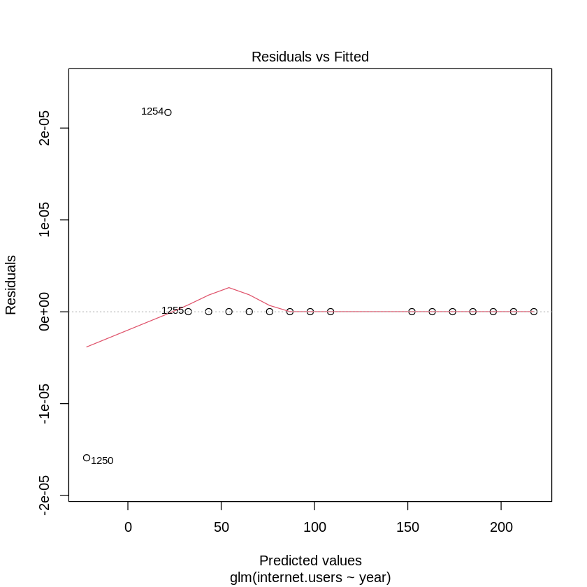

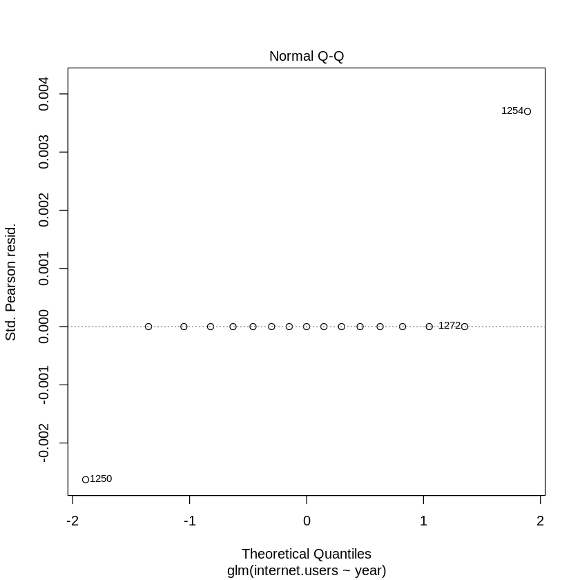

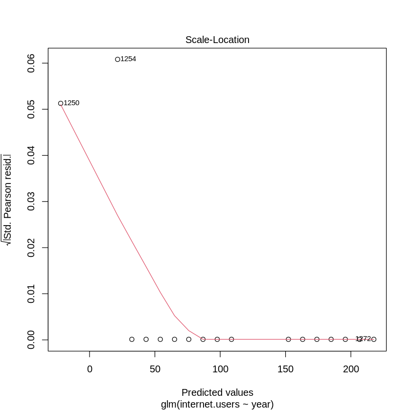

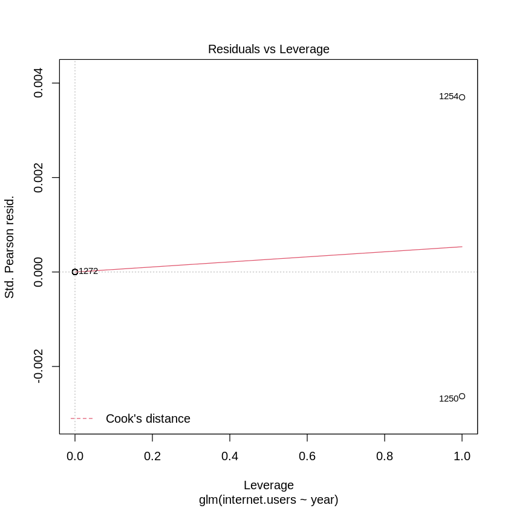

```r
plot(logistic_model)
```

# As we can clearly see the maximum R sqaure value for Belarus is produced by the **ExponentialModel** with

1. Residual standard error: 1.813 on 15 degrees of freedom
2. Multiple R-squared: 0.8515, Adjusted R-squared: 0.8416
3. F-statistic: 86.04 on 1 and 15 DF, p-value: 1.331e-07

# **Producing Results for Denmark Data**

# Fitting Linear Model for Denmark Data

```r
LinearModel.fit = lm(internet.users~year, data=Denmark_Data)
summary(LinearModel.fit)
```

```
Call:
lm(formula = internet.users ~ year, data = Denmark_Data)

Residuals:
    Min      1Q  Median      3Q     Max
-766856 -431447 -147249  515307  956208

Coefficients:
              Estimate Std. Error t value Pr(>|t|)
(Intercept) -594026677   35858402  -16.57 1.56e-13 ***
year            298143      17920   16.64 1.44e-13 ***
---
Signif. codes:  0 ‘***’ 0.001 ‘**’ 0.01 ‘*’ 0.05 ‘.’ 0.1 ‘ ’ 1

Residual standard error: 570100 on 21 degrees of freedom
Multiple R-squared:  0.9295,	Adjusted R-squared:  0.9261
F-statistic: 276.8 on 1 and 21 DF,  p-value: 1.436e-13
```

# Plotting Residuals Fits

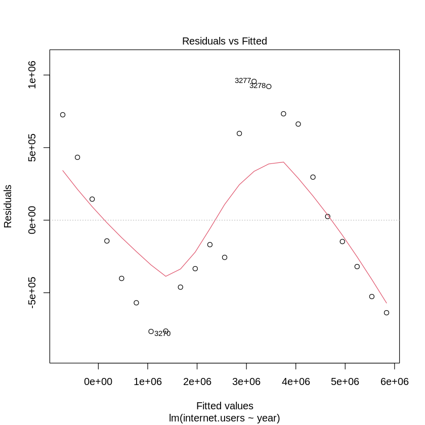

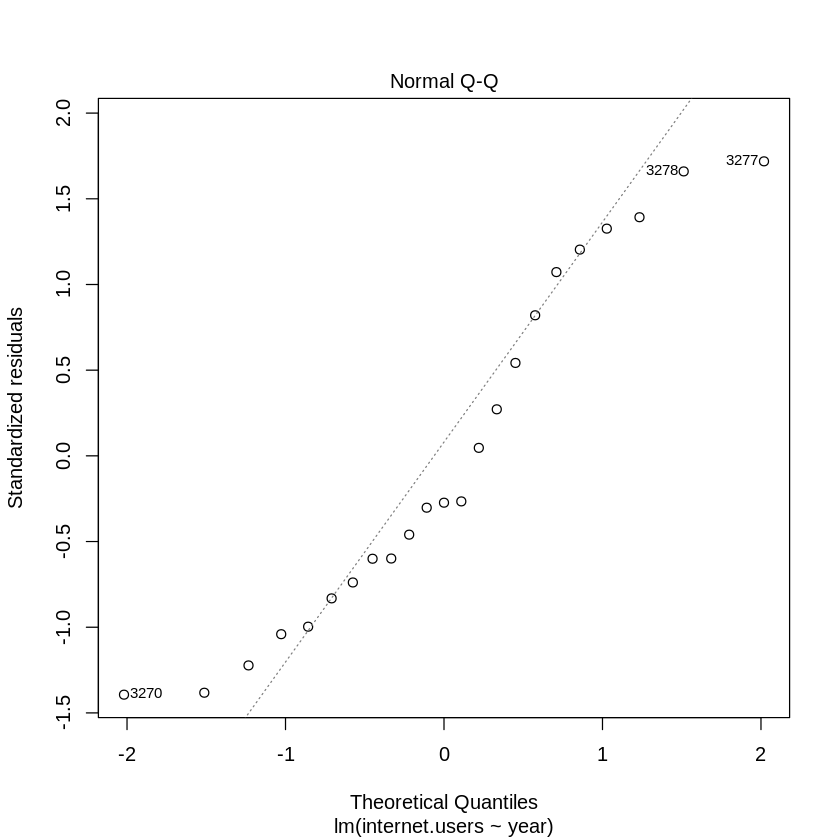

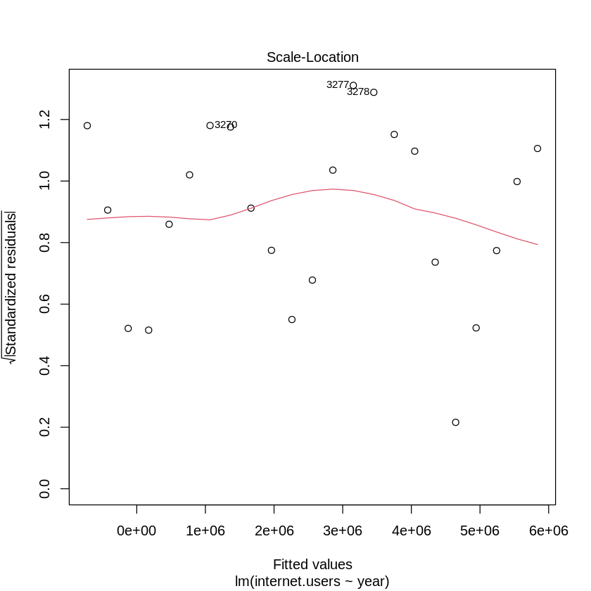

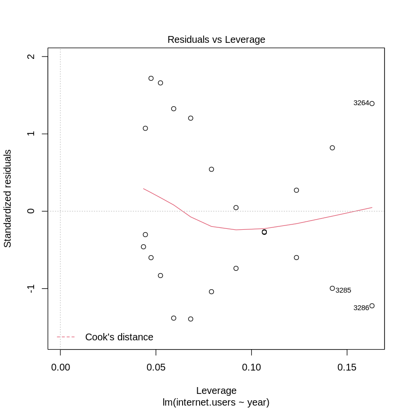

```r
plot(LinearModel.fit)  # Residuals, Fitted, ...
```

# Fitting ExponentialModel for Denmark Data

```r
ExponentialModel.fit = lm(log(internet.users)~year, data=Denmark_Data)
summary(ExponentialModel.fit)
```

```
Call:
lm(formula = log(internet.users) ~ year, data = Denmark_Data)

Residuals:
    Min      1Q  Median      3Q     Max
-1.7925 -0.9167  0.2333  0.9444  1.2805

Coefficients:
              Estimate Std. Error t value Pr(>|t|)
(Intercept) -589.47350   64.95540  -9.075 1.03e-08 ***
year           0.30140    0.03246   9.285 6.99e-09 ***
---
Signif. codes:  0 ‘***’ 0.001 ‘**’ 0.01 ‘*’ 0.05 ‘.’ 0.1 ‘ ’ 1

Residual standard error: 1.033 on 21 degrees of freedom
Multiple R-squared:  0.8041,	Adjusted R-squared:  0.7948
F-statistic: 86.21 on 1 and 21 DF,  p-value: 6.989e-09
```

# Plotting Residuals Fits

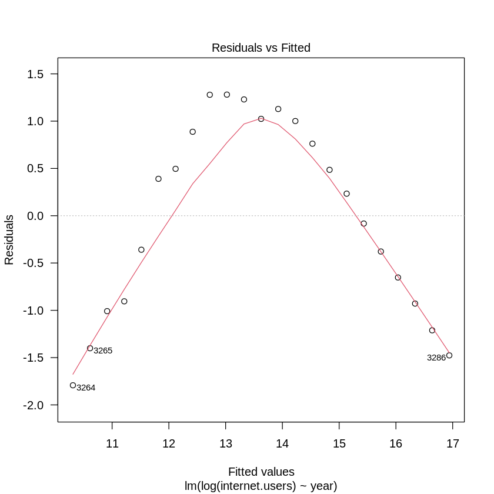

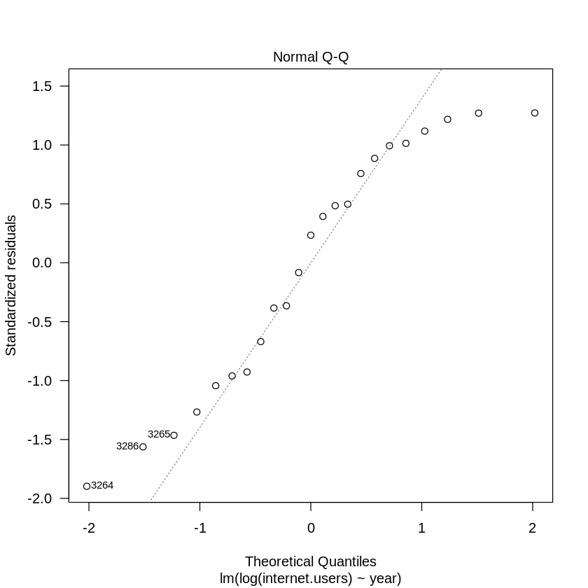

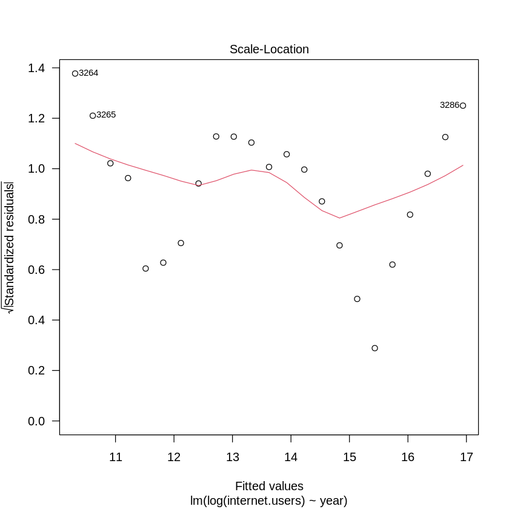

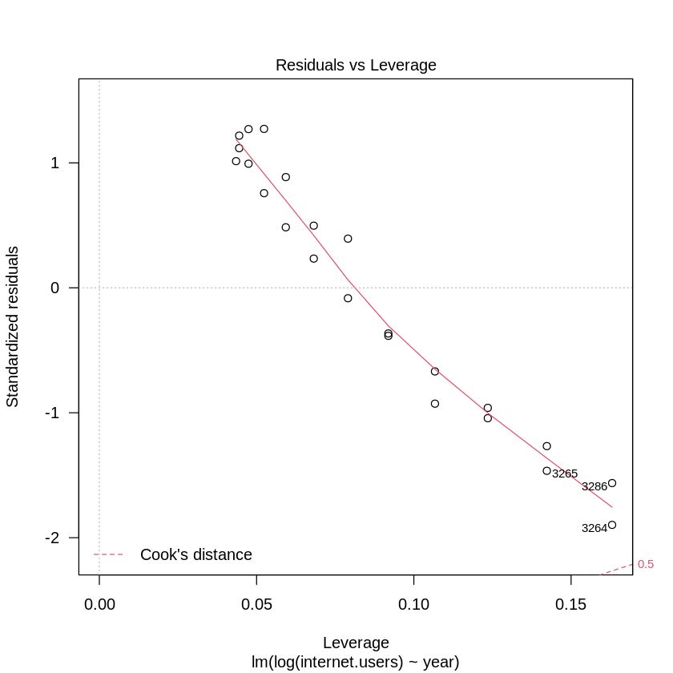

```r
plot(ExponentialModel.fit, las = 1) # Residuals, Fitted, ...
```

# Fitting Logistic Model on Denmark Data

```r
Denmark_Data$internet.users=factor(Denmark_Data$internet.users)

logistic_model <- glm(internet.users~year ,
                      data = Denmark_Data,
                      family = "binomial")
summary(logistic_model)
```

```
Call:
glm(formula = internet.users ~ year, family = "binomial", data = Denmark_Data)

Deviance Residuals:
      Min         1Q     Median         3Q        Max
-8.12e-05   2.10e-08   2.10e-08   2.10e-08   9.87e-05

Coefficients:
              Estimate Std. Error z value Pr(>|z|)
(Intercept) -7.697e+04  2.723e+07  -0.003    0.998
year         3.867e+01  1.368e+04   0.003    0.998

(Dispersion parameter for binomial family taken to be 1)

    Null deviance: 8.2269e+00  on 22  degrees of freedom
Residual deviance: 1.6335e-08  on 21  degrees of freedom
AIC: 4

Number of Fisher Scoring iterations: 25
```